# Week 2 Fantasy Football 10 Man Report

Welcome to the end of week 2! We'll be keeping things simple in this report: league stats, nothing else. If people want more NFL-centric information, let me know. Otherwise, let's jump right into it.

## League news

1. The bot is gone and in its place is my brother-in-law. Be nice.
2. League dues are due by September 21. See the Sleeper chat for where to send the $30 to.
3. Let's try to figure out what the last place punishment for this year will be ASAP.

### New & notable injuries

- QB **Joe Burrow** (PPR 15.86) is expected to miss up to 3 months with a Grade 3 turf toe injury; expect QB **Jake Browning** to be the Bengals starting quarter back until November at a minimum
  - **Ja'Marr Chase** (PPR 41.10) owners have reason to be worried: with Jake Browning as his QB in 2023, Chase averaged 5 receptions, 63 yards and 1 TD over seven weeks. I was going to say that the three game stretch where the two played together again in 2024 was cause for optimism, and then I actually ran the numbers: 7REC/64YDS/1TD. Gross.
- RB **Aaron Jones** (PPR 18) will miss at least 4 weeks with a hamstring injury after being placed on IR on September 16
  - QB **JJ McCarthy** (PPR 28.04) will miss week 3's game (vs Cinci); the severity of the injury is still not known

### Transactions

- WR **Garrett Wilson** to **Team Julius Peppers** for WR **DJ Moore**, WR **Jakobi Meyers**, RB **Jacory Croskey-Merritt**, and a **2026 1st Round Pick** on September 13, 2025

#### Notable waiver wire moves

- None; QB **Russell Wilson** (PPR 42.42) remains a high risk high reward option in the wire for QB-depleted squads

## Bench Stats

Everyone's favorite stat from last year is back--better than before and on a weekly basis.

For those that missed it or don't remember from last week, two things are being measured in this section. First, how far away were you from the *maximum number of points* (Max Points %) you could have scored this week--how many points you would have scored if you had a perfect start/sit percentage. The second metric is what that perfect start/sit lineup would have actually looked like (your Optimal Lineup). The goal of including the lineup itself is to give greater context to your Max Points %; you might have a single player account for a 10-15% decrease, which isn't *really* indicative of anything other than poor timing as opposed to something systemic in your lineup choices. Your team's performance in a given week is, of course, heavily reliant on luck (I'm looking at you, week 1 Ja'Marr Chase/Justin Jefferson...), but if your Optimal Lineup is consistently filled with players on your bench, it may be time to make some adjustments.

[output not shown]

**The Dallas Femboys**, **Julius Peppers**, and **Benningms** are this week's best bench managers, with accuracies of 91.33%, 91.30%, and 88.73%, respectively. On the other side of the coin, **Beaner Brigade** had a rough 72.59% accuracy.

It's worth noting that **Benningms** has had two weeks straight of good bench management and has a record of 1-1; the win coming this week in a game that had a margin of victory of only 4 points. I'd expect the luck to even out and for him to be a top team if this trend continues.

*Note: in the table below you can use the search bar to avoid having to click through multiple pages of results to find your team*

[figure not shown]

## Points Composition

Here you'll find a stacked bar chart that showcases which positions have been most valuable to your team up to this point (*hover or click on a segment of a given bar to view the stats!*).

As of now we're pretty evenly split on which teams are seeing the most value between their WR and RB rooms, although for now WRs are outscoring RBs--shocker in a PPR league, I know.

**Tush Pushin til it Hurts** is seeing abnormally low value out of their RB room--just 33.9 points across two weeks--though I'm not ready to say it's a sit/start accuracy issue. Although it's true that both of their start RBs should have been benched, they "only" missed out on ~16 points (and who could blame them for sitting Nick Chubb in his first year back and the horrific state of the Houston OL). The state of that entire RB room is one to keep an eye on.

On the topic of abnormalities, **Beaner Brigade** shocks yet again with a cumulative 3.2 points from his TE room. That's a 2-0 team that just blew out their week 2 matchup, in case anyone was wondering. Early season weirdness and all that.

In what is not at all surprising for Dallas Cowboys dick riders (present!), **Benningms** has the highest K score across the league with Brandon Aubrey; **Bryce04512** is not far behind, though.

[interactive chart not shown]

## Weekly Trends and Rankings

(*You can interact with this plot as well*)

Not much to really explore with this Points For (PF) line plot--it's pretty self-explanatory we're too early in the season to make heads or tails of it (who remembers how ridiculous the PF plot looked by the end of last year in the 6 man league?). Most teams saw an increase in PF; the sharpest drop off we saw this week was the 50 point drop in PF for **when in doubt jugg it out**. Both Aaron Jones and Courtland Sutton having horrible games can take a good deal of credit for that decline, probably.

[interactive chart not shown]

The real star of the show of these reports will, most likely, be the power rankings. I am going to preface this with the fact that no power rankings metric is perfect, and even still, power rankings for fantasy football is probably as imperfect a statistic that you could create. Still, I think there is merit to making one, and I am more than welcome to ideas on how you all think I can improve it.

Week 2 Power Rankings

Team

Power Rating

Rank

Rank Δ

xWins

Actual Wins

Max Points %

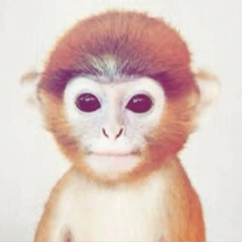

Julius Peppers

98.21

1

5

1.33

2

Tush Pushin til it Hurts

96.42

2

1

1.33

2

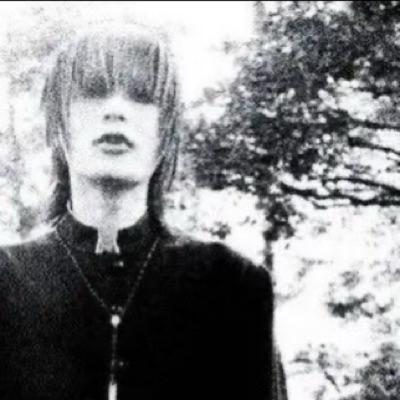

Beaner Brigrade

96.16

3

2

1.33

2

Benningms

94.29

4

0

1.33

1

[figure not shown]

The Dallas Femboys

91.54

5

-3

1.33

1

when in doubt jugg it out

88.41

6

-5

1.0

1

[figure not shown]

Bryce04512

75.99

7

3

0.67

1

[figure not shown]

drakemayelovers

74.20

8

-1

0.89

0

SDIYBT

68.65

9

-1

0.56

0

[figure not shown]

peepeepoopoo55

66.13

10

-1

0.22

0

Max Points percent is the percentage of points scored divided by the points you could have scored with your optimal lineup

xWins are expected wins based on points scored in a given week compared to the rest of the league

For those of you that will think "actually my ranking should be higher because *x*, *y*, and *z*", here's the formula I am using so that you can complain about it accurately:

$$\text{Power Rating} = \frac{(\text{Avg. Points For} * 6) + (\text{Cumulative Start/Sit Accuracy} * 2) + (\text{Win Percentage} * 2)}{10}$$

or, in other words, your power rating is a combination of the average number of points your team scores, how good you are at setting your lineups, and your win percentage. Teams that consistently score a high number of points but get unlucky in their matchups (i.e., play another team that just so happens to score even more than them) are punished less severely for those losses in this weighting scheme, provided that their start/sit accuracy is high (which it should be, given that PF is highly correlated with start/sit accuracy). Additionally, since this formula takes into account not a given week's start/sit accuracy but *your accuracy across the entire season*, a single bad performance shouldn't disproportionately impact your rating. I'll be sure to keep an eye on the rating's performance across the season and make tweaks as necessary.

last week, for example, **Benningms** had an xWins of ~1 because they scored more points than everybody in the league except their matchup.

And that does it for this week! Once more: if you have any suggestions on things you'd like to see, just shoot me a message, and good luck in your matchups this week!